# ARCANE - Incidence Calibration and Seeding Analysis

Novel pathogen introduction on the French inter-hospital transfer network

MESuRS/Cnam - Task 4.3

September 2026

# Methodology

## Study population and network

The French inter-hospital transfer network was derived from 2024 PMSI (Programme de Medicalisation des Systemes d’Information) administrative discharge data. The network comprises **2,529 hospitals** (etablissements de soins) including acute care (MCO - Medecine, Chirurgie, Obstetrique), rehabilitation (SSR - Soins de Suite et de Readaptation), psychiatric (PSY), home hospitalisation (HAD - Hospitalisation a Domicile), and mixed (MCO/SSR) facilities. Daily transfer counts between each pair of facilities were derived from rolling 7-day sums, divided by 7 to give daily averages and rounded to the nearest integer (minimum 1). Total network beds: 374,545.

## SIS transmission model

Within each hospital h on each day t, susceptible patients (S) can acquire colonisation from infected/colonised patients (I) according to a **frequency-dependent stochastic SIS (Susceptible-Infected-Susceptible)** process:

```
P(new colonisation | S, I, N) = 1 − exp(−beta x I/N)
```

where beta (beta) is the daily within-hospital transmission probability per susceptible-infectious contact (units: per day), N = S + I is total hospital occupancy, and new_inf ~ Binomial(S, p_inf). Biological decolonisation occurs at rate gamma (gamma) = 1/387 per day, corresponding to a mean carriage duration of 387 days for ESBL-producing Enterobacterales (ESBL-E). No patient isolation (alpha = 0) is assumed.

## Incidence calibration

**Incidence targets** were derived from ECDC EARS-Net 2022 antibiotic resistance carriage prevalence benchmarks, converted to hospital-acquired incidence per 1,000 patient-days using:

```
incidence = (gamma + 1/LOS) x (P_total − pi) x 1,000
```

where LOS is the network-weighted mean length of stay (9.28 days from PMSI data) and P_total is the ECDC carriage prevalence for each resistance tier. Three tiers are defined using ECDC official category boundaries:

Incidence calibration targets derived from ECDC EARS-Net 2022. CRE = Carbapenem-Resistant Enterobacterales. VRE = Vancomycin-Resistant Enterococci. MRSA = Methicillin-Resistant Staphylococcus aureus. ESBL-E = Extended-Spectrum Beta-Lactamase-producing Enterobacterales. pd = patient-days.

[output not shown]

## Seeding simulation

Seeding rules. NC = Network-central. FTR = Facility-type random. MCO = Medecine Chirurgie Obstetrique (acute care). SSR = Soins de Suite et de Readaptation (rehabilitation). MCO/SSR = mixed facility. All centrality metrics computed on the directed transfer network using igraph (betweenness: directed, unnormalised).

[output not shown]

**Simulation parameters:**

Seeding simulation parameters. SS = steady state.

[output not shown]

## Outcome metric definitions

All outcomes are computed per simulation replicate. Analyses use non-extinct replicates only unless stated otherwise.

Primary outcome metric definitions. I_loc = infected (colonised) patients per hospital. N_t = total occupied beds on day t. new_inf_t = new colonisations on day t. SS = steady state. pd = patient-days. HAI = healthcare-associated infection.

Metric

Abbreviation

Scale

Exact formula

Time window

Interpretation

Network steady-state incidence

net_ss_inc

National (bed-weighted)

mean[sum(new_inf_t)/sum(N_t) x 1,000] over last SS_WINDOW days

Last 30 days

National hospital-acquired incidence rate per 1,000 patient-days at near-endemic equilibrium. Directly comparable to SPARES and ECDC HAI surveillance.

Facility-level mean steady-state incidence

fac_ss_inc_mean

Facility (unweighted)

mean over active hospitals of [new_inf_t[h]/N_t[h] x 1,000], then mean over last 30 days

Last 30 days

Mean of per-hospital daily acquisition rates, giving equal weight to each facility regardless of size. Closer to facility-level HAI reporting.

Network cumulative incidence

net_cumul_inc

National (bed-weighted)

mean[sum(new_inf_t)/sum(N_t) x 1,000] over all Tmax days

All 732 days

Mean daily acquisition rate over the entire simulation. Reflects the integrated burden of colonisation throughout the epidemic trajectory, not just the end state.

Network steady-state prevalence

net_ss_prev_pct

National (bed-weighted)

mean[sum(I_loc_t)/total_beds x 100] over last 30 days

Last 30 days

Proportion of total network beds occupied by colonised patients at near-endemic equilibrium. NOTE: values above 100% indicate a simulation capacity overflow bug and are capped at 100% in all displays.

Facility-level mean steady-state prevalence

fac_ss_prev_mean_pct

Facility (unweighted)

mean over hospitals of [I_loc_t[h]/beds[h] x 100], then mean over last 30 days

Last 30 days

Mean of per-hospital colonisation proportions. Unweighted: a 10-bed rural facility counts the same as a 1,000-bed university hospital.

Extinction

ever_extinct

sum(I_loc) == 0 at any point during the simulation

Any day 1-732

Pathogen died out - no colonised patients remain. With pi=0 (novel pathogen), extinction occurs when the pathogen fails to establish through transfers and within-hospital transmission alone.

Steady-state reached

ss_reached

0.9 <= net_ss_inc / net_cumul_inc <= 1.1

Ratio of last-30d mean to overall mean

The epidemic has stabilised: the last 30-day incidence is within 10% of the overall mean. Ratio > 1.1 = still growing; ratio < 0.9 = declining.

## Results compilation

Local (PSOCK, Windows) and cluster (FORK, Linux) simulation results were compiled by `compile_seeding_novel.R`. Each source is loaded separately, tagged with a source label, and row-bound into a single `sim_summary` data frame. Each simulation replicate receives a globally unique identifier (`global_sim_id`) to prevent collision between local and cluster job indices. The compiled file saved to `Outputs/seeding_novel/compiled/` is the single input to this report.

# Part 1 - Calibration results

Beta grid search results. Incidence (inc) per 1,000 patient-days among non-extinct reps. SS = % of non-extinct reps reaching steady state. Prev = network prevalence on final day.

| beta (beta) | N reps | Extinct (%) | SS (%) | Inc median /1k pd | Inc Q25 | Inc Q75 | Prev median |
| --- | --- | --- | --- | --- | --- | --- | --- |
| 0.005 | 30 | 0 | 0.0 | 0.0058 | 0.0055 | 0.0059 | 0.0020 |
| 0.010 | 30 | 0 | 0.0 | 0.0165 | 0.0161 | 0.0168 | 0.0030 |
| 0.015 | 30 | 0 | 16.7 | 0.0475 | 0.0459 | 0.0482 | 0.0060 |
| 0.020 | 30 | 0 | 100.0 | 0.2092 | 0.2053 | 0.2198 | 0.0235 |
| 0.025 | 30 | 0 | 100.0 | 1.1921 | 1.1664 | 1.2284 | 0.1285 |
| 0.030 | 30 | 0 | 100.0 | 3.7179 | 3.6893 | 3.7633 | 0.3555 |
| 0.035 | 30 | 0 | 100.0 | 6.0723 | 6.0562 | 6.0837 | 0.5300 |
| 0.040 | 30 | 0 | 100.0 | 7.5785 | 7.5751 | 7.5837 | 0.6381 |
| 0.045 | 30 | 0 | 100.0 | 8.7478 | 8.7413 | 8.7532 | 0.7215 |
| 0.050 | 30 | 0 | 100.0 | 9.7445 | 9.7413 | 9.7496 | 0.7898 |
| 0.055 | 30 | 0 | 100.0 | 10.6283 | 10.6241 | 10.6334 | 0.8479 |
| 0.060 | 30 | 0 | 100.0 | 11.4184 | 11.4101 | 11.4255 | 0.8980 |
| 0.065 | 30 | 0 | 100.0 | 12.1374 | 12.1338 | 12.1438 | 0.9415 |
| 0.070 | 30 | 0 | 100.0 | 12.7999 | 12.7916 | 12.8023 | 0.9810 |
| 0.075 | 30 | 0 | 100.0 | 13.4086 | 13.3964 | 13.4144 | 1.0146 |
| 0.080 | 30 | 0 | 100.0 | 13.9770 | 13.9682 | 13.9803 | 1.0464 |
| 0.085 | 30 | 0 | 100.0 | 14.5161 | 14.5041 | 14.5209 | 1.0735 |
| 0.090 | 30 | 0 | 100.0 | 15.0129 | 15.0080 | 15.0225 | 1.0998 |
| 0.095 | 30 | 0 | 100.0 | 15.4884 | 15.4802 | 15.4953 | 1.1227 |
| 0.100 | 30 | 0 | 100.0 | 15.9400 | 15.9290 | 15.9419 | 1.1439 |
| 0.105 | 30 | 0 | 100.0 | 16.3636 | 16.3555 | 16.3710 | 1.1645 |
| 0.110 | 30 | 0 | 100.0 | 16.7754 | 16.7650 | 16.7791 | 1.1829 |
| 0.115 | 30 | 0 | 100.0 | 17.1606 | 17.1508 | 17.1697 | 1.2003 |
| 0.120 | 30 | 0 | 100.0 | 17.5328 | 17.5239 | 17.5392 | 1.2163 |
| 0.125 | 30 | 0 | 100.0 | 17.8921 | 17.8812 | 17.8958 | 1.2317 |
| 0.150 | 30 | 0 | 100.0 | 19.4781 | 19.4633 | 19.4894 | 1.2958 |
| 0.175 | 30 | 0 | 100.0 | 20.8075 | 20.8018 | 20.8145 | 1.3440 |
| 0.200 | 30 | 0 | 100.0 | 21.9592 | 21.9448 | 21.9654 | 1.3837 |
| 0.225 | 30 | 0 | 100.0 | 22.9725 | 22.9631 | 22.9824 | 1.4171 |
| 0.250 | 30 | 0 | 100.0 | 23.8895 | 23.8789 | 23.8993 | 1.4443 |
| 0.275 | 30 | 0 | 100.0 | 24.7470 | 24.7394 | 24.7547 | 1.4703 |
| 0.300 | 30 | 0 | 100.0 | 25.5814 | 25.5696 | 25.5934 | 1.4913 |
| 0.325 | 30 | 0 | 100.0 | 26.3484 | 26.3360 | 26.3702 | 1.5119 |
| 0.350 | 30 | 0 | 100.0 | 27.0398 | 27.0157 | 27.0511 | 1.5295 |

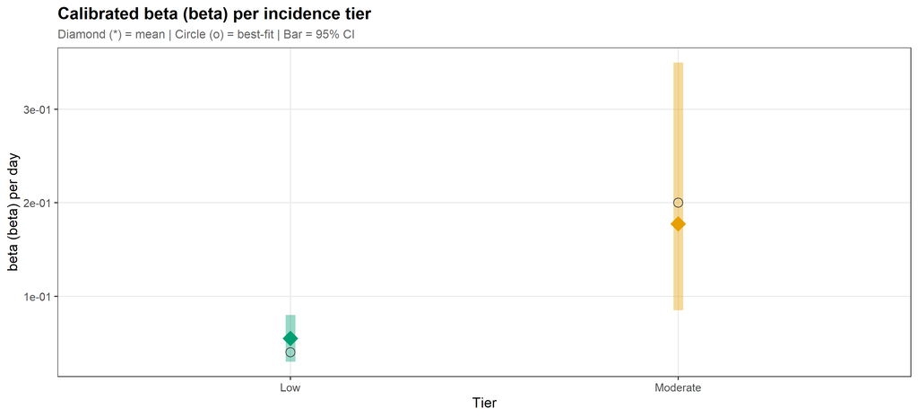

Tier analysis: recommended beta values per ECDC incidence tier.

| Tier | Inc low /1k pd | Inc high /1k pd | N reps | N jobs | Best beta | Mean beta | 95% CI low | 95% CI high | Mean inc achieved |
| --- | --- | --- | --- | --- | --- | --- | --- | --- | --- |
| Low | 1.300 | 14.299 | 331 | 10 | 0.04 | 0.05491 | 0.030 | 0.08 | 9.9949 |
| Moderate | 14.299 | 28.742 | 540 | 10 | 0.20 | 0.17750 | 0.085 | 0.35 | 19.9713 |

# Part 2 - Seeding simulation overview

**Scenario:** Novel pathogen | pi = 0 (no community importation)

**Sources:** cluster_job_01, cluster_job_02, cluster_job_03, cluster_job_04, cluster_job_05, cluster_job_06, cluster_job_07, cluster_job_08, cluster_job_09, cluster_job_10

**Total simulations:** 1200 | **Tiers:** Low / Moderate | **Seed rules:** 4

# Part 3 - Extinction and steady-state

## 3.1 Extinction probability by seed rule and tier

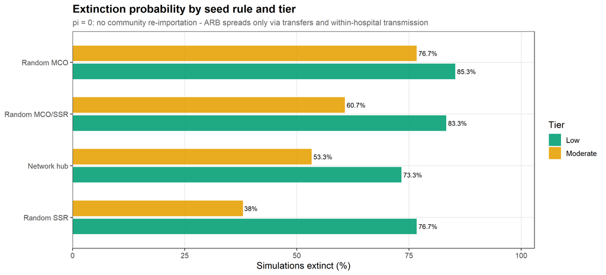

```
## > Steady-state indicator requires daily trajectories (traj_df). Load compiled RDS to enable.
```

# Part 4 - Primary outcome: Incidence per 1,000 patient-days

*Box = IQR (25th-75th percentile). Whiskers = 1.5 x IQR. Each dot = one simulation replicate. Non-extinct replicates only.*

## 4.1 National steady-state incidence (net_ss_inc) by seed rule

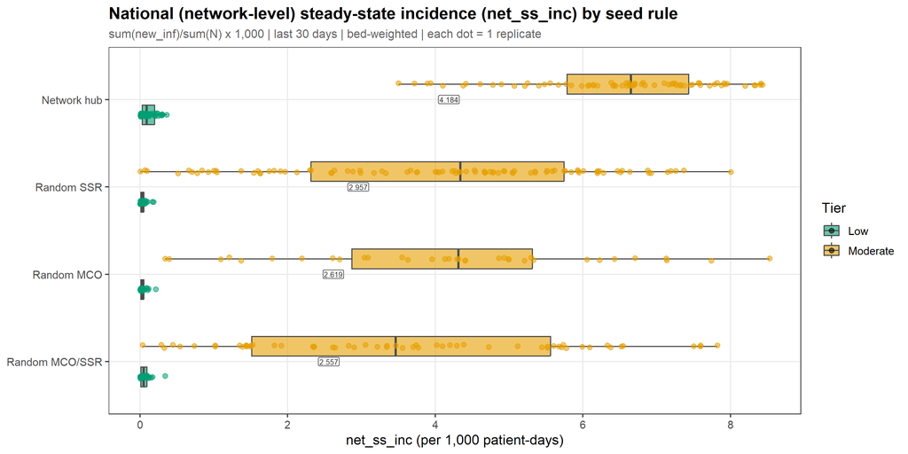

## 4.2 Facility-level mean steady-state incidence (fac_ss_inc_mean) by seed rule

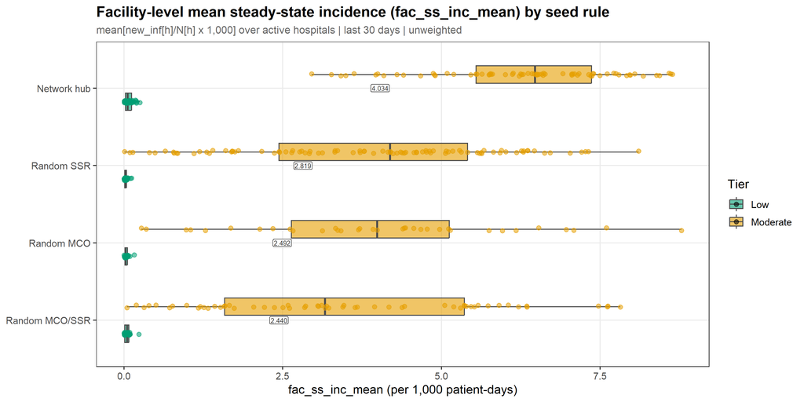

## 4.3 National vs facility-level incidence - seeding type comparison

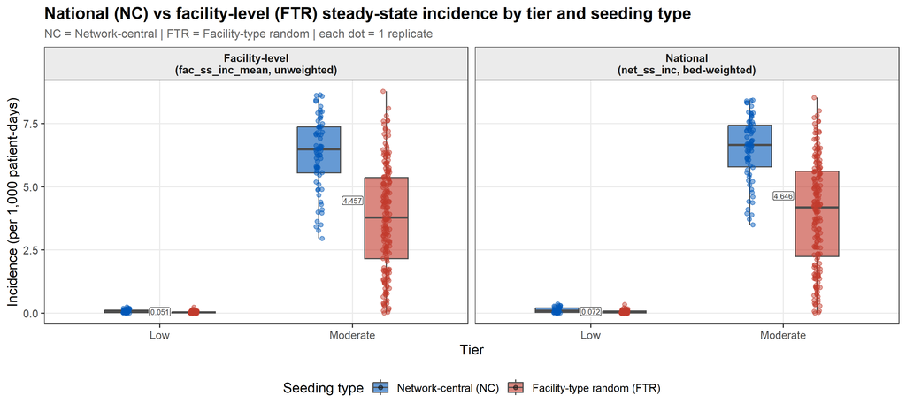

## 4.4 Cumulative incidence (net_cumul_inc) over 732 days

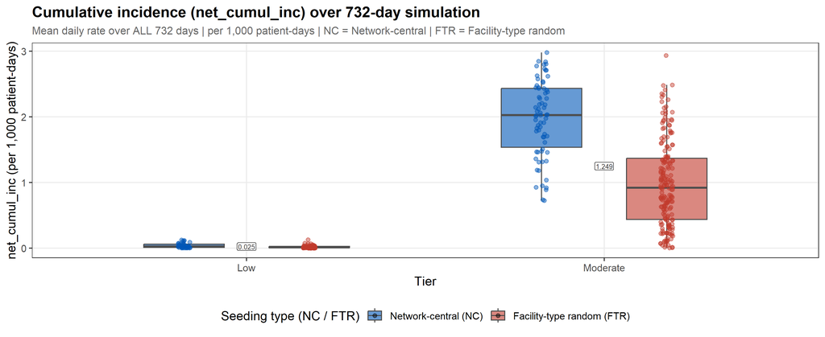

# Part 5 - Prevalence (capped at 100%)

> **Note:** Network-level prevalence (net_ss_prev_pct) and facility-level prevalence (fac_ss_prev_mean_pct) values above 100% are a **simulation capacity overflow artefact**: inter-hospital transfers can temporarily exceed a hospital’s bed capacity when multiple source hospitals simultaneously route patients to the same destination. All prevalence values are capped at 100% in displays below. Incidence metrics (Part 4) are not affected.

## 5.1 National prevalence (net_ss_prev_pct, capped) by seed rule

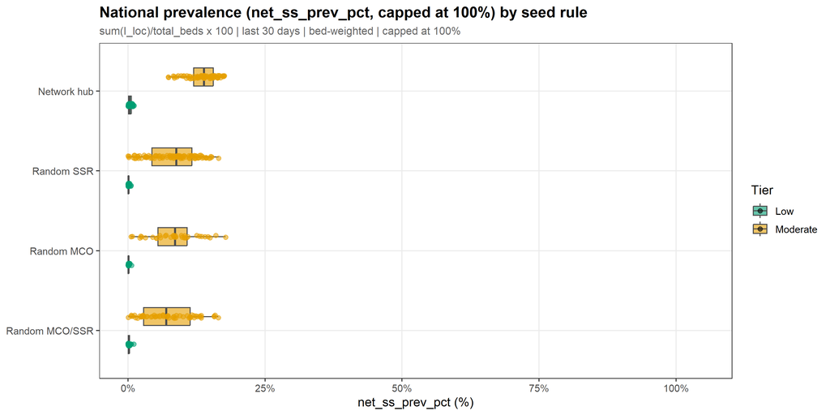

## 5.2 Facility-level prevalence (fac_ss_prev_mean_pct, capped) by seed rule

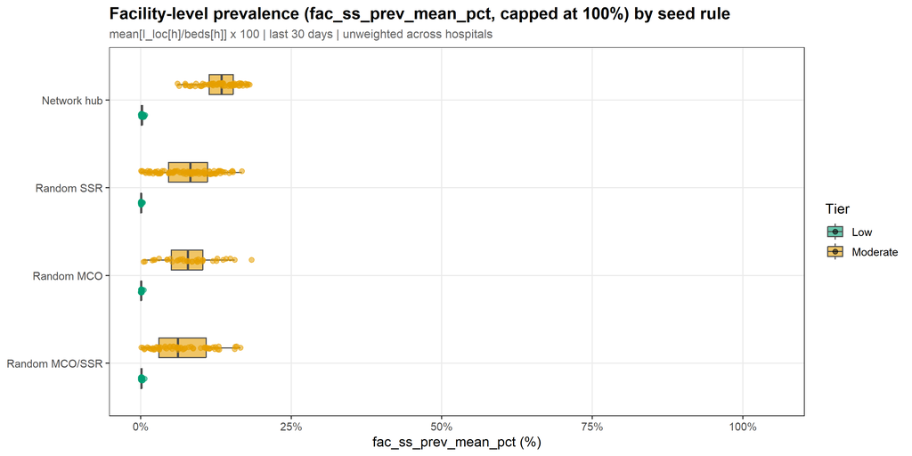

# Part 6 - Epidemic trajectories

## 6.1 National incidence trajectory (net_inc)

*Thin lines = individual replicates. Thick line = mean. Shaded = 95% CI. Vertical dashed = mean day reaching SS (90% of final level).*

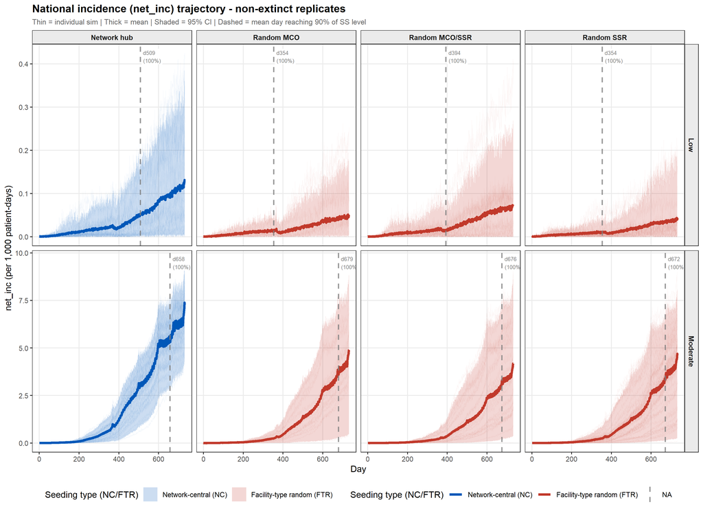

## 6.2 Facility-level incidence trajectory (fac_inc_mean)

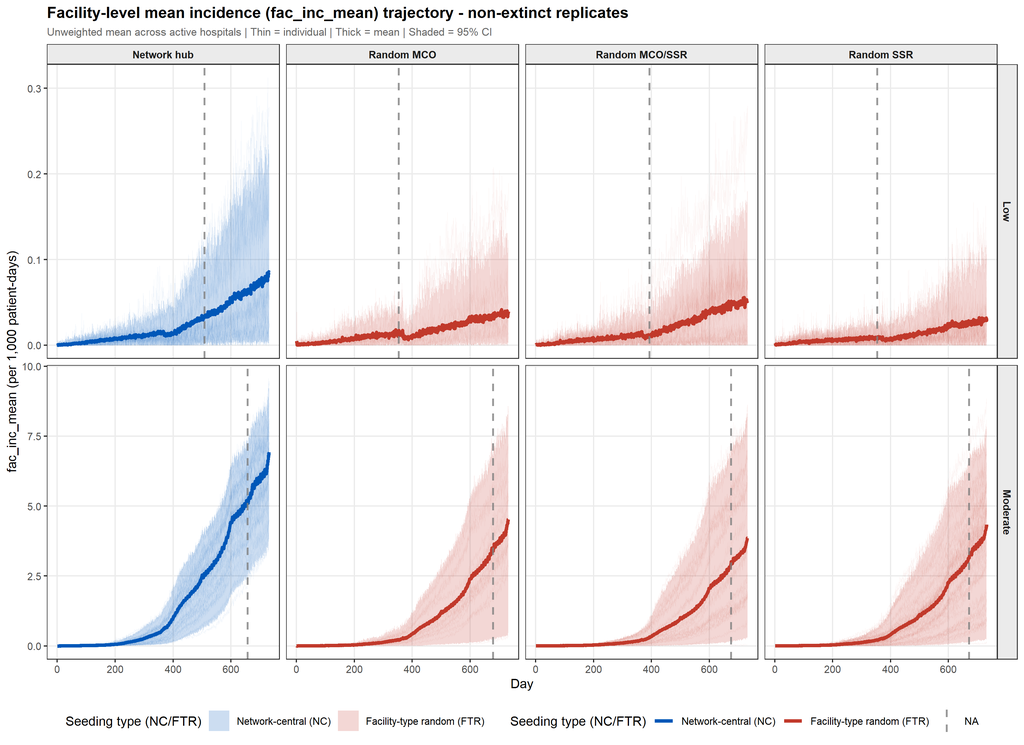

## 6.3 Steady-state day summary

Steady state (SS) day per simulation cell. SS = first day net_inc >= 90% of that replicate’s net_ss_inc. NC = Network-central. FTR = Facility-type random. % reps reached SS = fraction of non-extinct replicates crossing the threshold before day 732.

| Tier | Seeding type | Seed rule | Mean SS day | % reps reached SS |
| --- | --- | --- | --- | --- |
| Low | NA | Network hub | 509 | 100 |
|  |  | Random MCO | 354 | 100 |
|  |  | Random MCO/SSR | 394 | 100 |
|  |  | Random SSR | 354 | 100 |
| Moderate |  | Network hub | 658 | 100 |
|  |  | Random MCO | 679 | 100 |
|  |  | Random MCO/SSR | 676 | 100 |
|  |  | Random SSR | 672 | 100 |

# Part 7 - Summary table

Summary table. Mean (SD) across non-extinct replicates. NC = Network-central. FTR = Facility-type random. net_ss_inc = national bed-weighted SS incidence. fac_ss_inc_mean = facility-level unweighted SS incidence. net_cumul_inc = mean daily national incidence over 732 days. net_ss_prev = national prevalence (capped at 100%). /1k pd = per 1,000 patient-days. SS = last 30 days.

| Tier | Seeding type | Seed rule | N | Extinct (%) | SS reached (%) | net_ss_inc /1k pd | fac_ss_inc_mean /1k pd | net_cumul_inc /1k pd | net_ss_prev % (capped) |
| --- | --- | --- | --- | --- | --- | --- | --- | --- | --- |
| Low | Network-central (NC) | Network hub | 150 | 73.3% | 8.7% | 0.117 (0.101) | 0.078 (0.065) | 0.038 (0.035) | 0.3 (0.3) |
|  | Facility-type random (FTR) | Random MCO | 150 | 85.3% | 6% | 0.046 (0.050) | 0.037 (0.036) | 0.018 (0.018) | 0.1 (0.1) |
|  |  | Random MCO/SSR | 150 | 83.3% | 6% | 0.068 (0.075) | 0.051 (0.051) | 0.025 (0.028) | 0.2 (0.2) |
|  |  | Random SSR | 150 | 76.7% | 6% | 0.039 (0.042) | 0.029 (0.026) | 0.015 (0.014) | 0.1 (0.1) |
| Moderate | Network-central (NC) | Network hub | 150 | 53.3% | 7.3% | 6.508 (1.260) | 6.295 (1.434) | 1.973 (0.581) | 13.5 (2.6) |
|  | Facility-type random (FTR) | Random MCO | 150 | 76.7% | 1.3% | 4.236 (2.080) | 4.036 (2.082) | 1.053 (0.666) | 8.5 (4.4) |
|  |  | Random MCO/SSR | 150 | 60.7% | 0% | 3.612 (2.174) | 3.452 (2.149) | 0.895 (0.661) | 7.2 (4.6) |
|  |  | Random SSR | 150 | 38% | 2.7% | 4.056 (2.061) | 3.869 (2.009) | 1.003 (0.639) | 8.1 (4.3) |

# Part 9 - Export

Saved to seeding_novel_report_table.csv

| tier | seed_type | seed_rule | n_total | n_alive | pct_extinct | pct_ss_reached | mean_net_ss_inc | sd_net_ss_inc | mean_fac_ss_inc | sd_fac_ss_inc | mean_net_cumul_inc | sd_net_cumul_inc | mean_net_prev_capped | sd_net_prev_capped |
| --- | --- | --- | --- | --- | --- | --- | --- | --- | --- | --- | --- | --- | --- | --- |
| Low | Network-central (NC) | Network hub | 150 | 40 | 73.3 | 8.7 | 0.1171 | 0.1008 | 0.0775 | 0.0652 | 0.0380 | 0.0349 | 0.35 | 0.31 |
| Low | Facility-type random (FTR) | Random MCO | 150 | 22 | 85.3 | 6.0 | 0.0463 | 0.0501 | 0.0369 | 0.0360 | 0.0180 | 0.0177 | 0.13 | 0.14 |
| Low | Facility-type random (FTR) | Random MCO/SSR | 150 | 25 | 83.3 | 6.0 | 0.0680 | 0.0752 | 0.0506 | 0.0508 | 0.0255 | 0.0280 | 0.21 | 0.24 |
| Low | Facility-type random (FTR) | Random SSR | 150 | 35 | 76.7 | 6.0 | 0.0388 | 0.0424 | 0.0289 | 0.0256 | 0.0146 | 0.0144 | 0.11 | 0.13 |
| Moderate | Network-central (NC) | Network hub | 150 | 70 | 53.3 | 7.3 | 6.5077 | 1.2603 | 6.2948 | 1.4339 | 1.9733 | 0.5806 | 13.53 | 2.63 |
| Moderate | Facility-type random (FTR) | Random MCO | 150 | 35 | 76.7 | 1.3 | 4.2358 | 2.0801 | 4.0357 | 2.0823 | 1.0534 | 0.6664 | 8.53 | 4.41 |
| Moderate | Facility-type random (FTR) | Random MCO/SSR | 150 | 59 | 60.7 | 0.0 | 3.6118 | 2.1741 | 3.4524 | 2.1489 | 0.8953 | 0.6613 | 7.24 | 4.59 |
| Moderate | Facility-type random (FTR) | Random SSR | 150 | 93 | 38.0 | 2.7 | 4.0557 | 2.0613 | 3.8691 | 2.0088 | 1.0031 | 0.6389 | 8.14 | 4.35 |

*2026-09-07 16:05 | Sims: 1200 | Non-extinct: 379 (31.6%) | SS: 57 of 379 | Traj: 878,400*